# Funciones Meinxer

Erick Soto

# 1. Función: obtener_datos

**Descripción:** Descarga precios ajustados de un ticker desde Yahoo Finance, calcula sus rendimientos logarítmicos y exporta un CSV.

**Parámetros:**

- ticker Símbolo financiero, p.ej. “AAPL” o “MSFT”
- fecha_inicio “YYYY-MM-DD”
- fecha_fin “YYYY-MM-DD”

```r
obtener_datos <- function(ticker, fecha_inicio, fecha_fin) {

  #Descargamos precios
  precios <- tq_get(ticker, get = "stock.prices", from = fecha_inicio, to = fecha_fin)

  # Calculamos log-rendimientos y los agregamos como columna
  precios <- precios %>%
    arrange(date) %>%
    mutate(
      returns = c(NA, diff(log(adjusted)))  # Log-rendimientos diarios
    )

  #Creamos CSV
  ruta <- "C:/Users/erick/OneDrive/Documentos/Tesis/meixner/meixner_functions/data"
  nombre_csv <- paste0("precios_rendimientos_", tolower(ticker),".csv")
  write.csv(precios, file.path(ruta,nombre_csv))

  return(precios)
}
```

```r
fecha_inicio<- "2018-01-02"
fecha_fin<- "2025-08-01"

obtener_datos(ticker = "GFINBURO.MX", fecha_inicio, fecha_fin)
```

```
## # A tibble: 1,907 × 9
##    symbol      date        open  high   low close  volume adjusted   returns
##    <chr>       <date>     <dbl> <dbl> <dbl> <dbl>   <dbl>    <dbl>     <dbl>
##  1 GFINBURO.MX 2018-01-02  32.5  34.0  32.1  33.8 1706338     32.1 NA
##  2 GFINBURO.MX 2018-01-03  33.8  34.7  33.1  34.1 2988567     32.3  0.00678
##  3 GFINBURO.MX 2018-01-04  34.0  34.9  34.0  34.7 3095284     32.9  0.0183
##  4 GFINBURO.MX 2018-01-05  34.8  35.0  34.5  34.9 1939586     33.1  0.00718
##  5 GFINBURO.MX 2018-01-08  35.0  35.2  33.9  34.4 1931432     32.6 -0.0150
##  6 GFINBURO.MX 2018-01-09  34.1  35.0  33.4  34.9 1582011     33.1  0.0127
##  7 GFINBURO.MX 2018-01-10  34.7  34.7  33.5  33.8 2266458     32.0 -0.0315
##  8 GFINBURO.MX 2018-01-11  34.0  34.2  33.0  33.6 2807032     31.9 -0.00475
##  9 GFINBURO.MX 2018-01-12  33.7  34.8  33.6  34.6 3547749     32.8  0.0284
## 10 GFINBURO.MX 2018-01-15  34.7  34.7  34.5  34.6  700014     32.8  0.000578
## # ℹ 1,897 more rows
```

```r
obtener_datos(ticker = "GCARSOA1.MX", fecha_inicio, fecha_fin)
```

```
## # A tibble: 1,907 × 9
##    symbol      date        open  high   low close volume adjusted  returns
##    <chr>       <date>     <dbl> <dbl> <dbl> <dbl>  <dbl>    <dbl>    <dbl>
##  1 GCARSOA1.MX 2018-01-02  66    66    64.0  65.6 313388     60.1 NA
##  2 GCARSOA1.MX 2018-01-03  65.8  66.3  65    66.1 306672     60.7  0.00866
##  3 GCARSOA1.MX 2018-01-04  66.3  67.2  65.6  65.8 358542     60.3 -0.00561
##  4 GCARSOA1.MX 2018-01-05  66.4  67.5  66.1  67.4 222745     61.8  0.0251
##  5 GCARSOA1.MX 2018-01-08  67.4  68.5  66.3  68.3 462732     62.6  0.0128
##  6 GCARSOA1.MX 2018-01-09  68.3  68.3  66.5  67.2 299137     61.7 -0.0155
##  7 GCARSOA1.MX 2018-01-10  67.6  67.6  64.9  65.1 328977     59.7 -0.0325
##  8 GCARSOA1.MX 2018-01-11  66.3  67.0  64.3  66.6 342985     61.1  0.0235
##  9 GCARSOA1.MX 2018-01-12  65.3  68    65.2  66.1 563992     60.6 -0.00814
## 10 GCARSOA1.MX 2018-01-15  66.1  66.3  65.3  65.4 134930     60.0 -0.0105
## # ℹ 1,897 more rows
```

```r
rendimientos_inbursa <- read.csv("C:/Users/erick/OneDrive/Documentos/Tesis/meixner/meixner_functions/data/precios_rendimientos_gfinburo.mx.csv")

rendimientos_carso <- read.csv("C:/Users/erick/OneDrive/Documentos/Tesis/meixner/meixner_functions/data/precios_rendimientos_gcarsoa1.mx.csv")
```

## 1.1 Función: ultimo_precio

```r
obten_ultimo_precio <- function(tickers, primera_fecha, ultima_fecha){

descarga_precios <- tickers |>
  tidyquant::tq_get(get  = "stock.prices",
                    from = primera_fecha,
                    to = ultima_fecha)

df_ultimo_precio <- descarga_precios |>
  dplyr::select(symbol, date, adjusted) |>
  dplyr::mutate(date = as.character(date)) |>
  dplyr::arrange(date) |>
  tail(n=1)

names(df_ultimo_precio) <- c("accion", "fecha", "precio")
return(df_ultimo_precio)
}
```

```r
S0_inbursa <- obten_ultimo_precio("GFINBURO.MX", fecha_inicio, fecha_fin); S0_inbursa
```

```
## # A tibble: 1 × 3
##   accion      fecha      precio
##   <chr>       <chr>       <dbl>
## 1 GFINBURO.MX 2025-07-31   48.6
```

```r
S0_carso <- obten_ultimo_precio("GCARSOA1.MX", fecha_inicio, fecha_fin); S0_carso
```

```
## # A tibble: 1 × 3
##   accion      fecha      precio
##   <chr>       <chr>       <dbl>
## 1 GCARSOA1.MX 2025-07-31   134.
```

# 2. Función: descriptivos

**Parámetros:**

**Valor de retorno:**

```r
calculo_descriptivas <- function(df) {

  # Extraer la columna
  x <- df$returns

  # Crear un data frame con estadísticas descriptivas
  resumen <- data.frame(
    Media = mean(x, na.rm = TRUE),
    Mediana = median(x, na.rm = TRUE),
    Varianza = var(x, na.rm = TRUE),
    Desviacion_Estandar = sd(x, na.rm = TRUE),
    Minimo = min(x, na.rm = TRUE),
    Maximo = max(x, na.rm = TRUE),
    Q1 = quantile(x, 0.25, na.rm = TRUE),
    Q3 = quantile(x, 0.75, na.rm = TRUE),
    Asimetria = skewness(x, na.rm = TRUE),
    Curtosis = kurtosis(x, na.rm = TRUE)
  )

  return(resumen)
}
```

```r
desc_carso <- calculo_descriptivas(rendimientos_carso); desc_carso
```

```
##            Media      Mediana     Varianza Desviacion_Estandar     Minimo
## 25% 0.0004208261 0.0005495707 0.0005685109          0.02384347 -0.1612681
##        Maximo          Q1         Q3    Asimetria Curtosis
## 25% 0.1150124 -0.01375019 0.01384402 -0.001820616  5.37098
```

```r
desc_inbur <- calculo_descriptivas(rendimientos_inbursa);desc_inbur
```

```
##           Media Mediana     Varianza Desviacion_Estandar    Minimo     Maximo
## 25% 0.000217708       0 0.0004619739          0.02149358 -0.168154 0.09413898
##             Q1         Q3  Asimetria Curtosis
## 25% -0.0118825 0.01140889 -0.2105355 6.648152
```

# 3. Función: graficos

**Descripción:** Utiliza el dataframe de rendimientos para generar archivos png con histrograma, densidad, historico y grafico de velas historico y el Q1 de 2025

**Parámetros:**

- Data Frame de los rendimientos

**Valor de retorno:**

```r
graficos <- function(df) {

  stopifnot(all(c("date","returns","symbol","adjusted") %in% names(df)))

  # Asegura tipos
  if (inherits(df$date, "POSIXt")) df$date <- as.Date(df$date)
  if (is.character(df$date)) df$date <- as.Date(df$date)
  df$returns[is.na(df$returns)] <- 0
  ticker <- as.character(unique(df$symbol))[1]

  outdir <- "C:/Users/erick/OneDrive/Documentos/Tesis/meixner/meixner_functions/outputs"


  # -------- Gráfico histórico (usa df, no rendimientos_carso) --------
  g_precio <- ggplot(df, aes(x = date, y = adjusted)) +
    geom_line(color = "darkblue") +
    labs(title = paste0("Historico ticker: ", ticker),
         x = "Fecha", y = "Precio (MXN)") +
    scale_x_date(date_breaks = "6 months", date_labels = "%b-%Y") +
    theme_classic()

  ggsave(file.path(outdir, paste0(ticker, "_historico.png")),
         plot = g_precio, width = 12, height = 4, dpi = 300)

  # -------- Histograma y densidad --------
  png(file.path(outdir, paste0(ticker, "_histograma.png")),
      width = 1200, height = 800)
  x <- na.omit(df$returns)
  hist(x, breaks = 80, freq = FALSE, col = "#98F5FF",
       main = paste0("Histograma y Densidad - ", ticker),
       xlab = "Rendimientos", ylab = "Densidad")
  lines(stats::density(x), col = "#8B0000", lty = 2, lwd = 2)
  dev.off()

  # -------- Gráficos de velas --------
  # Asegura string simple
  tick <- as.character(ticker)

  g_vela_q1 <- quantmod::getSymbols(tick,
                                    from = "2025-01-02",
                                    to   = "2025-03-31",
                                    periodicity = "daily",
                                    auto.assign = FALSE)

  png(file.path(outdir, paste0(tick, "_velas_Q1.png")),
      width = 1200, height = 1200)
  quantmod::chartSeries(g_vela_q1,
                        name = paste0("Q1 - 2025 ", tick),
                        theme = "white",
                        up.col = "#66CD00",
                        dn.col = "firebrick3")
  dev.off()

  g_vela_hist <- quantmod::getSymbols(tick,
                                      from = "2018-01-02",
                                      to   = "2024-12-31",
                                      periodicity = "monthly",
                                      auto.assign = FALSE)

  png(file.path(outdir, paste0(tick, "_velas_historico.png")),
      width = 1200, height = 1200)
  quantmod::chartSeries(g_vela_hist,
                        name = paste0("Historico ", tick),
                        theme = "white",
                        up.col = "#66CD00",
                        dn.col = "firebrick3")
  dev.off()

  return(list(g_precio, g_vela_hist, g_vela_q1))
}
```

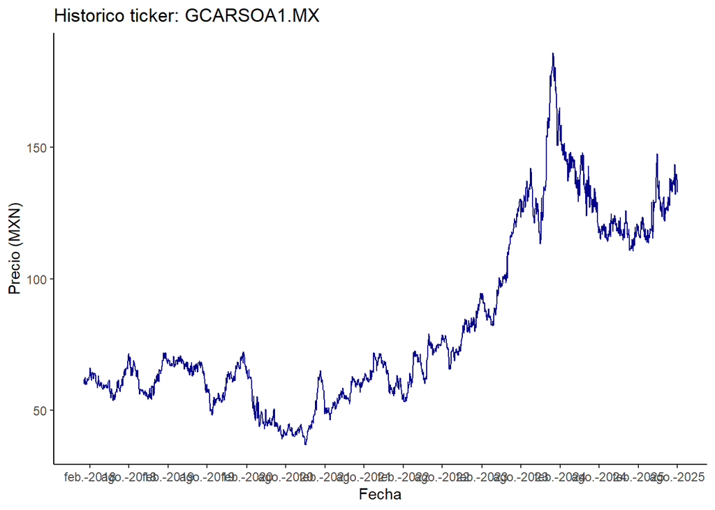

[output not shown]

[output cut: 241 more lines]

[output not shown]

```r
graficos(rendimientos_carso)
```

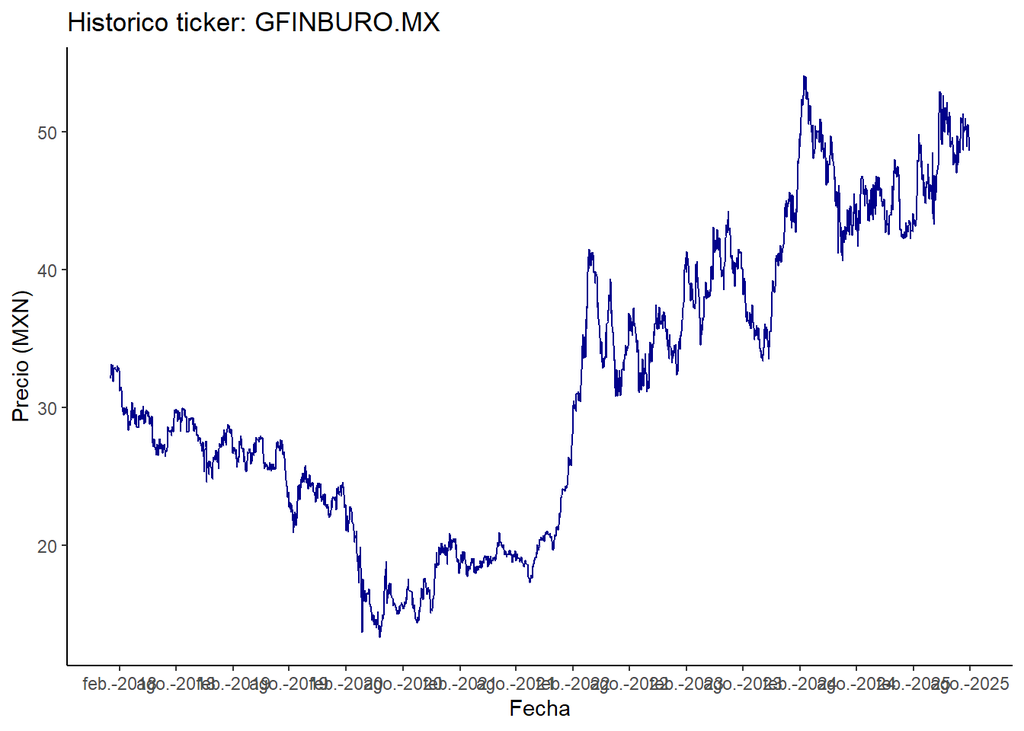

[output not shown]

[output cut: 241 more lines]

[output not shown]

```r
graficos(rendimientos_inbursa)
```

# 4. Función: estimacion_parametros

## 4.1 Meixner

**Descripción:** Utiliza el dataframe de descriptivos para estimar parametros de la distribucion meixner

**Parámetros:** - Data Frame de los descriptivos

**Valor de retorno:** - Vector con los parámetros Meixner estimados

#### Nota: restringir parametros

```r
estim_params_meixner <- function(descriptivos_part){

    # Extrae los descriptivos de la tabla de descriptivos
    media <- descriptivos_part$Media
    desv_est <- descriptivos_part$Desviacion_Estandar
    ske <- descriptivos_part$Asimetria
    kurt <- descriptivos_part$Curtosis

    # Calcula los estimadores para la distribución Meixner
    d <- 1/(kurt - (ske^2) -3)
    b <- sign(ske)*acos(2 - d*(kurt - 3))
    a <- desv_est*sqrt((1+cos(b))/d)
    m <- media - a*d*tan(b/2)

    params_meixner <- c(a, b, d, m)
    return(params_meixner)
    }
```

```r
par_meixner_carso <- estim_params_meixner(desc_carso); par_meixner_carso
```

```
## [1]  0.051921580 -0.001672129  0.421767054  0.000439135
```

```r
par_meixner_inbursa <- estim_params_meixner(desc_inbur); par_meixner_inbursa
```

```
## [1]  0.057526255 -0.157001747  0.277482847  0.001473362
```

## 4.2 Gaussiana

**Descripción:** Utiliza el dataframe de descriptivos para estimar parametros de la distribucion normal

**Parámetros:**

- Data Frame de los descriptivos

**Valor de retorno:**

- Vector con los parámetros normal estimados ($\hat{\mu}, \hat{\sigma}$)

```r
estim_params_normal <- function(descriptivos_part){
  media <- descriptivos_part$Media
  desv_est <- descriptivos_part$Desviacion_Estandar
  params_normal <- c(media, desv_est)
return(params_normal)
}
```

```r
par_normal_carso <- estim_params_normal(desc_carso); par_normal_carso
```

```
## [1] 0.0004208261 0.0238434657
```

```r
par_normal_inbursa <-estim_params_normal(desc_inbur); par_normal_inbursa
```

```
## [1] 0.000217708 0.021493577
```

# 5. Función: Ecuación númerica martingala

**Descripción:** Utiliza el vector de parametros estimados meixner para resolver la ecuación númerica martingala y devolver la theta de Esscher.

**Parámetros:**

- Vector de parametros estimados $\hat{a}, \hat{b}, \hat{d}, \hat{m}$ y la tasa libre de riesgo $r$.

**Valor de retorno:**

- Valor: $\theta$

```r
vect_params <- par_meixner_carso
a <- vect_params[1]
b <- vect_params[2]
d <- vect_params[3]
m <- vect_params[4]

ecuacion_martingala_meixner <- function(x){
  ecuacion_martingala<-log(cos((a*x + b)/2)) - log(cos((a*x + a + b)/2)) - (r-m)/(2*d)
}

#objeto_raiz <- uniroot(ecuacion_martingala_meixner, c(-15,15))

#theta_essch <- objeto_raiz$root; theta_essch

#Error en uniroot(ecuacion_martingala_meixner, c(5, 15)):
  #f() values at end points not of opposite sign
```

```r
calculo_theta_esscher <- function(vect_params, r) {
  a <- vect_params[1]; b <- vect_params[2]
  d <- vect_params[3]; m <- vect_params[4]

  f <- function(x) {
    t1 <- (a*x + b)/2
    t2 <- (a*(x + 1) + b)/2
    val <- log(cos(t1)) - log(cos(t2)) - (r - m)/(2*d)
    return(val)
  }

  # 1) Intervalo de validez (intersección)
  I1 <- sort(c((-pi - b)/a, ( pi - b)/a))
  I2 <- sort(c((-pi - b - a)/a, ( pi - b - a)/a))
  L <- max(I1[1], I2[1]); U <- min(I1[2], I2[2])
  if (L >= U) stop("Sin intersección de dominio para theta.")

  # 2) Buscar cambios de signo en un grid
  grid <- seq(L, U, length.out = 2000)
  y <- f(grid)
  ok <- is.finite(y)
  roots <- c()

  # Detecta cambios de signo entre puntos finitos
  idx <- which(ok[-length(ok)] & ok[-1] & (y[-length(y)] * y[-1] <= 0))
  for (i in idx) {
    a_i <- grid[i]; b_i <- grid[i+1]
    # Evita extremos no finitos
    if (is.finite(f(a_i)) && is.finite(f(b_i))) {
      rr <- try(uniroot(f, c(a_i, b_i))$root, silent = TRUE)
      if (!inherits(rr, "try-error")) roots <- c(roots, rr)
    }
  }

  if (length(roots) == 0) stop("No se encontró raíz en el dominio válido.")
  # 3) Elegir la más cercana a 0 (criterio usual)
  roots[which.min(abs(roots))]
}
```

```r
r <- 0.085
theta_inbursa <- calculo_theta_esscher(par_meixner_inbursa, r); theta_inbursa
```

```
## [1] 50.26312
```

```r
theta_carso <- calculo_theta_esscher(par_meixner_carso, r); theta_carso
```

```
## [1] 50.26932
```

# 6. Función: Parametros riesgo - neutro

## 6.1 Meixner

**Parámetros:**

- Vector de parametros estimados $\hat{a}, \hat{b}, \hat{d}, \hat{m}$ y la theta de Esscher $\theta$.

**Valor de retorno:** - Un vector con los parámetros riesgo neutro de las distr. Meixner

```r
calculo_params_rn_meixner <- function(vect_params, theta){
  # Parametros riesgo neutro
  a <- vect_params[1]
  b <- vect_params[2]
  d <- vect_params[3]
  m <- vect_params[4]
  b_essch <- (a*theta) + b
  params_rn <- c(a, b_essch, d, m)
  names(params_rn) <- c("a", "b", "d", "m")
  return(params_rn)
}
```

```r
par_rn_meixner_inbursa <- calculo_params_rn_meixner(par_meixner_inbursa, theta_inbursa); par_rn_meixner_inbursa
```

```
##           a           b           d           m
## 0.057526255 2.734447395 0.277482847 0.001473362
```

```r
par_rn_meixner_carso <- calculo_params_rn_meixner(par_meixner_carso, theta_carso); par_rn_meixner_carso
```

```
##           a           b           d           m
## 0.051921580 2.608390227 0.421767054 0.000439135
```

## 6.2 Gaussiana

**Parámetros:**

- Vector de parametros estimados normal $\hat{\mu}, \hat{\sigma}$ y la tasa libre de riesgo $r$.

**Valor de retorno:** - Un vector con los parámetros riesgo neutro de las distr. Normal

```r
calculo_params_rn_normal <- function(vect_params, r){
  mu <- vect_params[1]
  sigma <- vect_params[2]
  mu_rn <- r - (1/2)*(sigma^2)
  sigma_rn <- sigma
  params_rn <- c(mu_rn, sigma_rn)
  names(params_rn) <- c("mu_normal", "sigma_normal")
  return(params_rn)
}
```

```r
par_rn_normal_carso <- calculo_params_rn_normal(par_normal_carso, r); par_rn_normal_carso
```

```
##    mu_normal sigma_normal
##   0.08471574   0.02384347
```

```r
par_rn_nomal_inbursa <- calculo_params_rn_normal(par_normal_inbursa, r); par_normal_inbursa
```

```
## [1] 0.000217708 0.021493577
```

# 7. Funciones: Densidad Meixner

## 7.1 Cálculos de las densidades y distribución Meixner ajustadas

**Parámetros:**

- Vector de parámetros mundo real, vector de parámetros riesgo neutro y dataframe de rendimientos del activo

**Valor de reotrno:**

- Dataframe con cuatro columnas - mallado de puntos, densidad real, distribución real y densidad riesgo neutro

```r
calculo_densidad_distribucion_meixner <- function(vect_params,
                                                  vect_params_rn,
                                                  df_rendimientos_activos){

    a <- vect_params[1]
    b <- vect_params[2]
    d <- vect_params[3]
    m <- vect_params[4]

    a_rn <- vect_params_rn[1]
    b_rn <- vect_params_rn[2]
    d_rn <- vect_params_rn[3]
    m_rn <- vect_params_rn[4]

    rendimientos <- na.omit(df_rendimientos_activos$returns)

    # Cálculo de la densidad Meixner ajustada
    x <- seq(from = min(rendimientos), to = max(rendimientos), length.out = 150)
    distr <- Runuran::udmeixner(alpha=a, beta=b, delta=d, mu=m)
    gen <- Runuran::pinvd.new(distr)
    valores_densidad <- Runuran::ud(gen, x)
    # Cálculo de la distribucion Meixner ajustada
    valores_distribucion <- Runuran::up(gen, x)

    # Cálculo de la densidad Meixner riesgo neutro
    distr_rn <- Runuran::udmeixner(alpha=a_rn, beta=b_rn, delta=d_rn, mu=m_rn)
    gen_rn <- Runuran::pinvd.new(distr_rn)
    valores_densidad_rn <- Runuran::ud(gen_rn, x)

    df_densidad_ajustada <- data.frame(x = x,
                                       valores_densidad = valores_densidad,
                                       valores_distribucion = valores_distribucion,
                                       valores_densidad_rn = valores_densidad_rn)

    return(df_densidad_ajustada)
}
```

```r
densidad_meixner_carso <- calculo_densidad_distribucion_meixner(par_meixner_carso, par_rn_meixner_carso, rendimientos_carso); head(densidad_meixner_carso)
```

```
##            x valores_densidad valores_distribucion valores_densidad_rn
## 1 -0.1612681      0.001465332         2.387849e-05        1.402615e-07
## 2 -0.1594139      0.001642198         2.675642e-05        1.725477e-07
## 3 -0.1575597      0.001840452         2.998174e-05        2.122702e-07
## 4 -0.1557054      0.002062685         3.359648e-05        2.611431e-07
## 5 -0.1538512      0.002311806         3.764775e-05        3.212757e-07
## 6 -0.1519970      0.002591074         4.218836e-05        3.952641e-07
```

```r
densidad_meixner_inbursa <- calculo_densidad_distribucion_meixner(par_meixner_inbursa, par_rn_meixner_inbursa, rendimientos_inbursa); head(densidad_meixner_inbursa)
```

```
##            x valores_densidad valores_distribucion valores_densidad_rn
## 1 -0.1681540      0.001483821         2.733450e-05        1.213460e-07
## 2 -0.1663937      0.001633348         3.007604e-05        1.459316e-07
## 3 -0.1646333      0.001798033         3.309394e-05        1.755073e-07
## 4 -0.1628730      0.001979424         3.641620e-05        2.110878e-07
## 5 -0.1611126      0.002179229         4.007372e-05        2.538949e-07
## 6 -0.1593522      0.002399331         4.410054e-05        3.053993e-07
```

## 7.2 Cálculo de cuantiles Meixner ajustada

**Parámetros:**

- Vector de parámetros mundo real y vector de rendimientos del activo

**Valor de reotrno:**

- Dataframe con dos columnas - cuantiles empíricos de los rendims y cuantiles ajustados

```r
calculo_cuantiles_distribucion_meixner <- function(vect_params, df_rendimientos_activo){

    a <- vect_params[1]
    b <- vect_params[2]
    d <- vect_params[3]
    m <- vect_params[4]

    rendimientos <- na.omit(df_rendimientos_activo$returns)

    x <- seq(from = min(rendimientos), to = max(rendimientos), length.out = 150)
    distr <- Runuran::udmeixner(alpha=a, beta=b, delta=d, mu=m)
    gen <- Runuran::pinvd.new(distr)
    n <- 150
    probas <- ((1:n)-0.5)/n
    cuantiles_empi <- quantile(rendimientos, probs = probas, na.rm = TRUE)
    names(cuantiles_empi) <- NULL
    cuantiles_teo <- Runuran::uq(gen, probas)
    df_cuantiles <- data.frame(cuant_empiricos = cuantiles_empi,
                               cuant_teoricos = cuantiles_teo)
    return(df_cuantiles)
}
```

```r
cuantiles_meixner_carso <- calculo_cuantiles_distribucion_meixner(par_meixner_carso, rendimientos_carso)

cuantiles_meixner_inbursa <- calculo_cuantiles_distribucion_meixner(par_meixner_inbursa, rendimientos_inbursa)
```

## 7.3 Graficos Meixner y Normal

```r
dibuja_distribuciones <- function(tick,
                                  tabla_descriptivos,
                                  df_rendimientos_activos,
                                  df_densidad_ajustada){

    descriptivos_part <- tabla_descriptivos
    media <- descriptivos_part$Media
    desv_est <- descriptivos_part$Desviacion_Estandar

    titulo_densidad <- glue::glue(
    'Densidades ajustadas ',
    "<span style='color:{color_modelo}'>**",nombre_modelo,"**</span>", " y ",
    "<span style='color:{color_gaussiano}'>**Normal**</span>"
    )

    titulo_distribucion <- glue::glue(
    'Distribuciones ajustadas ',
    "<span style='color:{color_modelo}'>**",nombre_modelo,"**</span>", " y ",
    "<span style='color:{color_gaussiano}'>**Normal**</span>"
    )

    titulo_qqnorm <- glue::glue(
    'Gráfico cuantil-cuantil ',
    "<span style='color:{color_gaussiano}'>**Normal**</span>"
    )

    titulo_densidad_rn <- glue::glue(
    'Densidad riesgo neutro ',
    "<span style='color:{color_modelo}'>**",nombre_modelo,"**</span>"
    )

    graf_densidad <- df_rendimientos_activos |>
      ggplot() +
      stat_density(aes(x = returns), alpha = 0.3, fill = "green") +
      stat_function(fun = dnorm, args = list(mean = media, sd = desv_est),
                    color = color_gaussiano) +
      geom_line(data = df_densidad_ajustada,
                aes(x = x, y = valores_densidad), color = color_modelo) +
      ggtitle(label = titulo_densidad, subtitle = tick) +
      xlab("") + ylab("") +
      theme_light() +
      theme(
        plot.title = ggtext::element_markdown()
    )

    graf_distribucion <- df_rendimientos_activos |>
      ggplot() +
      stat_function(fun = pnorm, args = list(mean = media, sd = desv_est),
                    color = color_gaussiano) +
      geom_line(data = df_densidad_ajustada,
                aes(x = x, y = valores_distribucion), color = color_modelo) +
      stat_ecdf(aes(x = returns), geom = "step", color  = "green") +
      ggtitle(label = titulo_distribucion, subtitle = tick) +
      xlab("") + ylab("") +
      theme_light() +
      theme(
        plot.title = ggtext::element_markdown()
    )

    graf_qqnorm <- df_rendimientos_activos %>% ggplot(aes(sample = returns)) +
      stat_qq_line(color = color_gaussiano) +
      stat_qq(color = "green", size = 1) +
      ggtitle(label = titulo_qqnorm, subtitle = tick) +
      xlab("") + ylab("") +
      theme_light() +
      theme(
        plot.title = ggtext::element_markdown()
    )

    graf_densidad_rn <- df_rendimientos_activos |>
      ggplot() +
      stat_density(aes(x = returns), alpha = 0.2, fill = "green") +
      geom_line(data = df_densidad_ajustada,
                aes(x = x, y = valores_densidad), color = color_modelo, linetype="twodash") +
      geom_line(data = df_densidad_ajustada,
                aes(x = x, y = valores_densidad_rn), color = color_modelo) +
      ggtitle(label = titulo_densidad_rn, subtitle = tick) +
      xlab("") + ylab("") +
      theme_light() +
      theme(
        plot.title = ggtext::element_markdown()
    )

    lista_retorno <- list(graf_densidad, graf_distribucion, graf_qqnorm, graf_densidad_rn)
    names(lista_retorno) <- c("densidad",
                              "distribucion",
                              "CuantilNormal",
                              "densidadRiesgoNeutro")
    return(lista_retorno)
}
```

```r
dibuja_densidad_rn_normal <- function(tick,
                                      df_rendimientos_activos,
                                      vector_params_normal,
                                      vector_params_rn_normal){

  media <- vector_params_normal[1]
  desv_est <- vector_params_normal[2]

  media_rn <- vector_params_rn_normal[1]
  desv_est_rn <- vector_params_rn_normal[2]

  titulo_densidad_rn_normal <- glue::glue(
  'Densidad riesgo neutro ',
  "<span style='color:{color_gaussiano}'>**Normal**</span>"
  )

  graf_densidad_rn_normal <- df_rendimientos_activos |>
    ggplot() +
    stat_density(aes(x = returns), alpha = 0.2, fill = "green") +
    stat_function(fun = dnorm, args = list(mean = media, sd = desv_est),
                  color = color_gaussiano, linetype="twodash") +
    stat_function(fun = dnorm, args = list(mean = media_rn, sd = desv_est_rn),
                  color = color_gaussiano) +
    ggtitle(label = titulo_densidad_rn_normal, subtitle = tick) +
    xlab("") + ylab("") +
    theme_light() +
    theme(
      plot.title = ggtext::element_markdown()
  )
  return(graf_densidad_rn_normal)
}
```

```r
  dibuja_cuantiles_meixner <- function(tick, df_cuantiles){

  titulo_cuantil <- glue::glue(
  'Gráfico cuantil-cuantil ',
  "<span style='color:{color_modelo}'>**",nombre_modelo,"**</span>"
  )

  graf_cuantiles <- df_cuantiles %>% ggplot() +
    geom_abline(slope = 1, color=color_modelo) +
    geom_point(aes(x = cuant_empiricos, y = cuant_teoricos), color = "green") +
    ggtitle(label = titulo_cuantil, subtitle = tick) +
    xlab("") + ylab("") +
    theme_light() +
    theme(
      plot.title = ggtext::element_markdown()
  )

  return(graf_cuantiles)
}
```

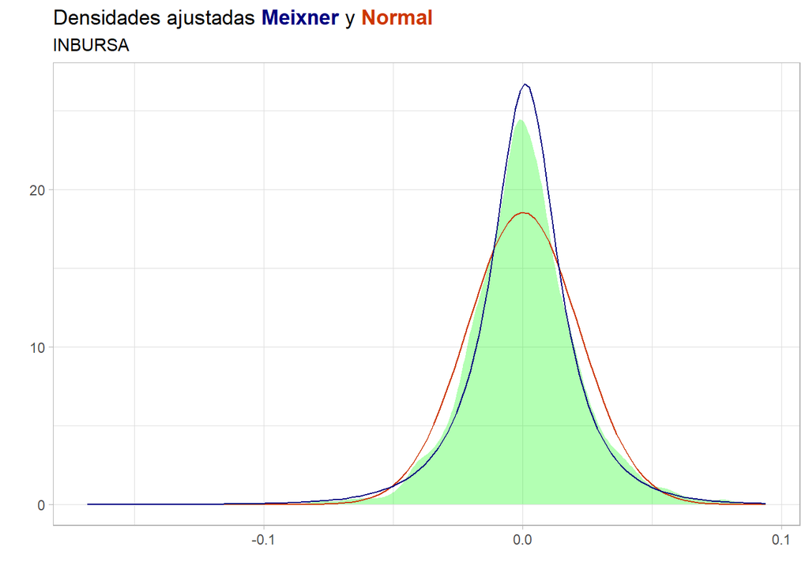

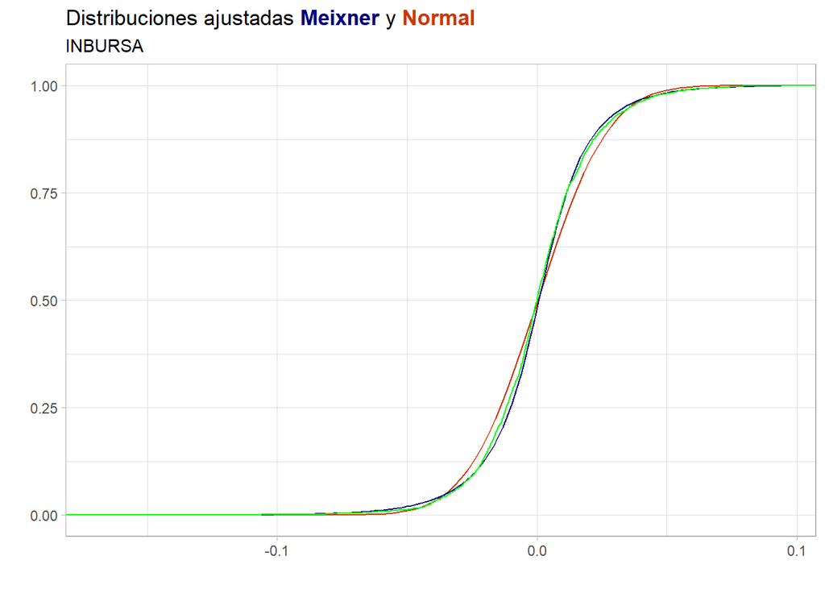

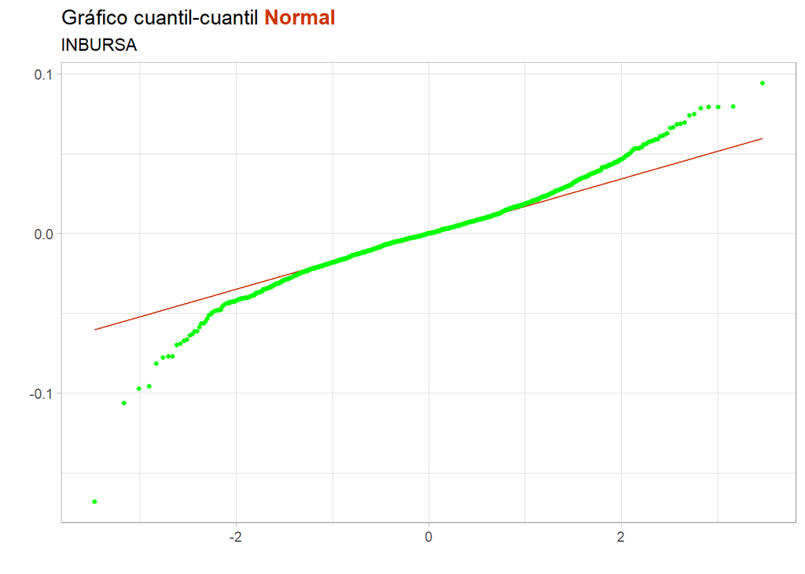

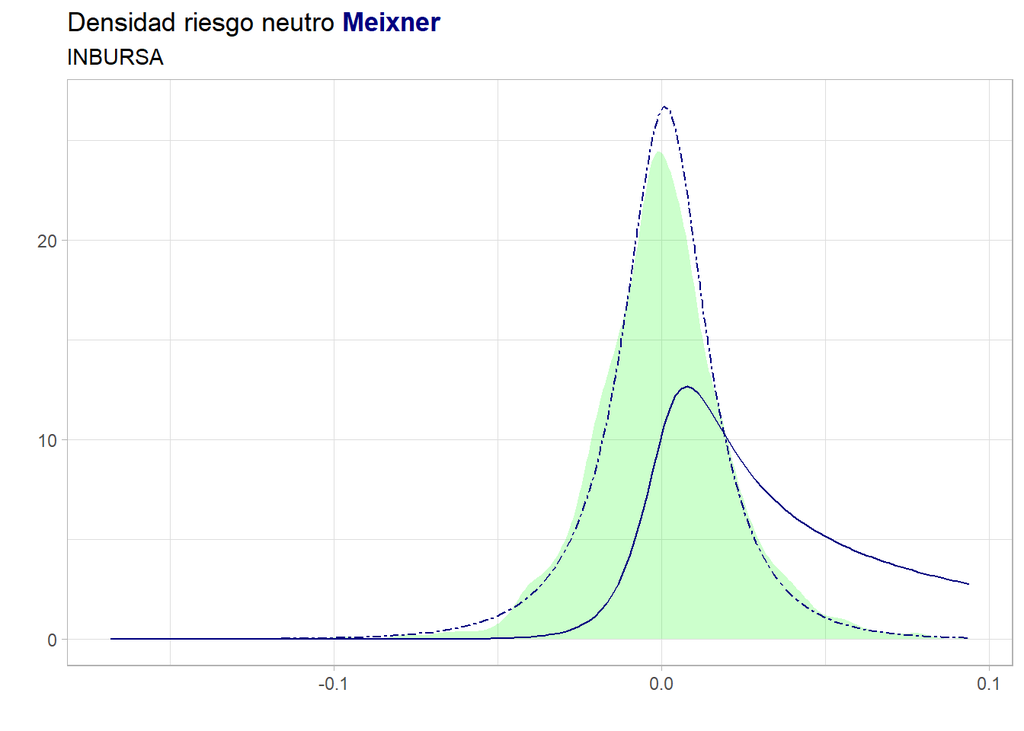

```r
color_gaussiano <- "orangered3"
# Nombre del modelo Meixner
nombre_modelo <- "Meixner"
# Color del modelo Meixner
color_modelo <- "navyblue"
dibuja_distribuciones("INBURSA", desc_inbur, rendimientos_inbursa, densidad_meixner_inbursa)
```

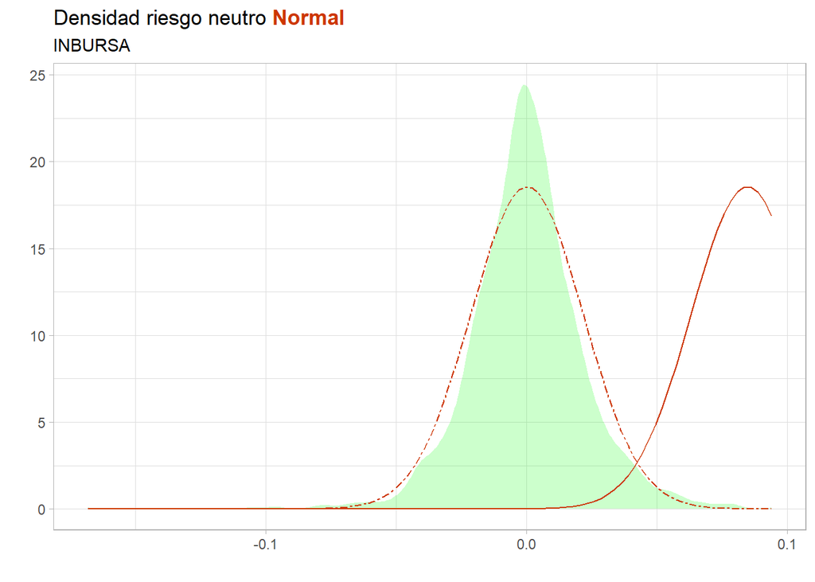

```r
dibuja_densidad_rn_normal("INBURSA", rendimientos_inbursa, par_normal_inbursa, par_rn_nomal_inbursa)
```

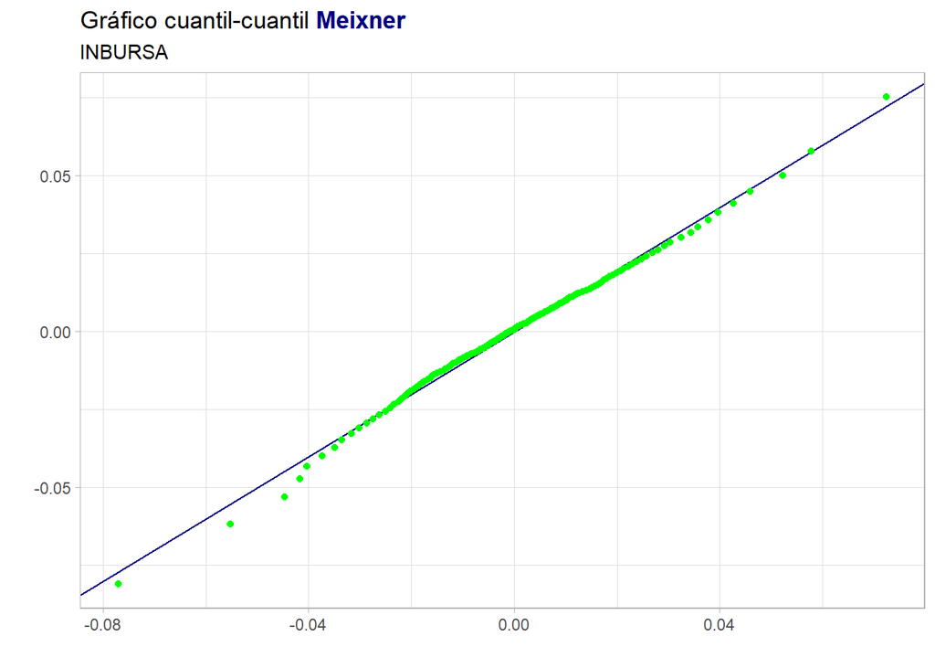

```r
dibuja_cuantiles_meixner("INBURSA", cuantiles_meixner_inbursa)
```

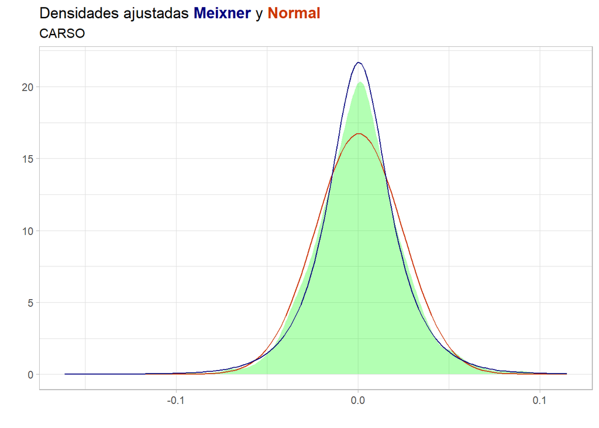

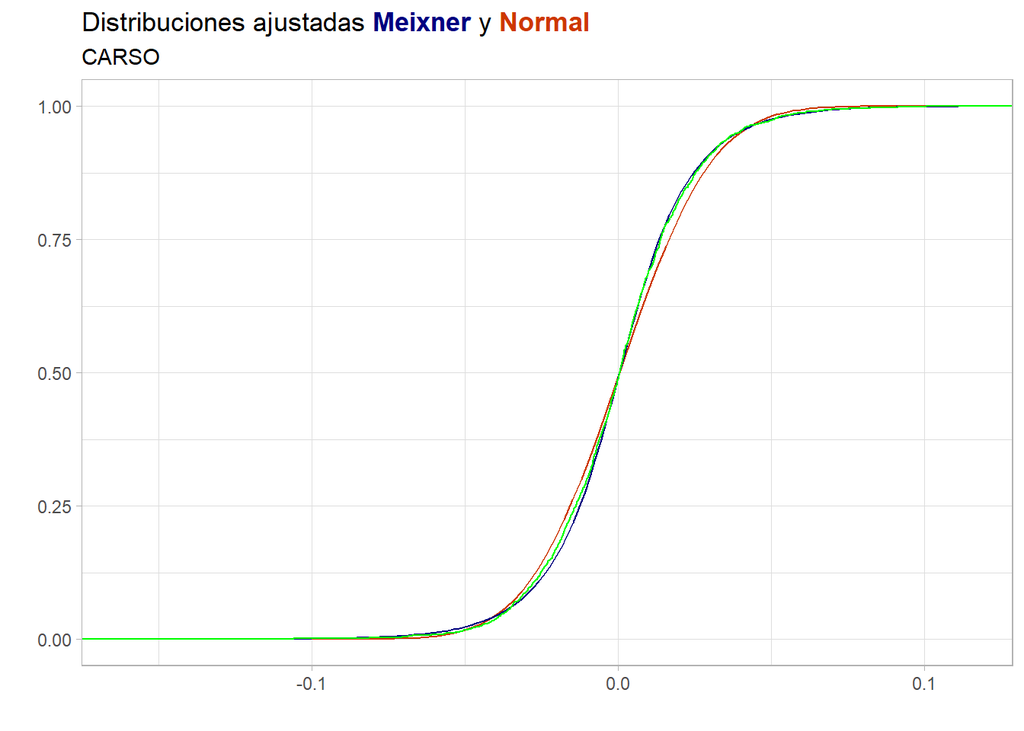

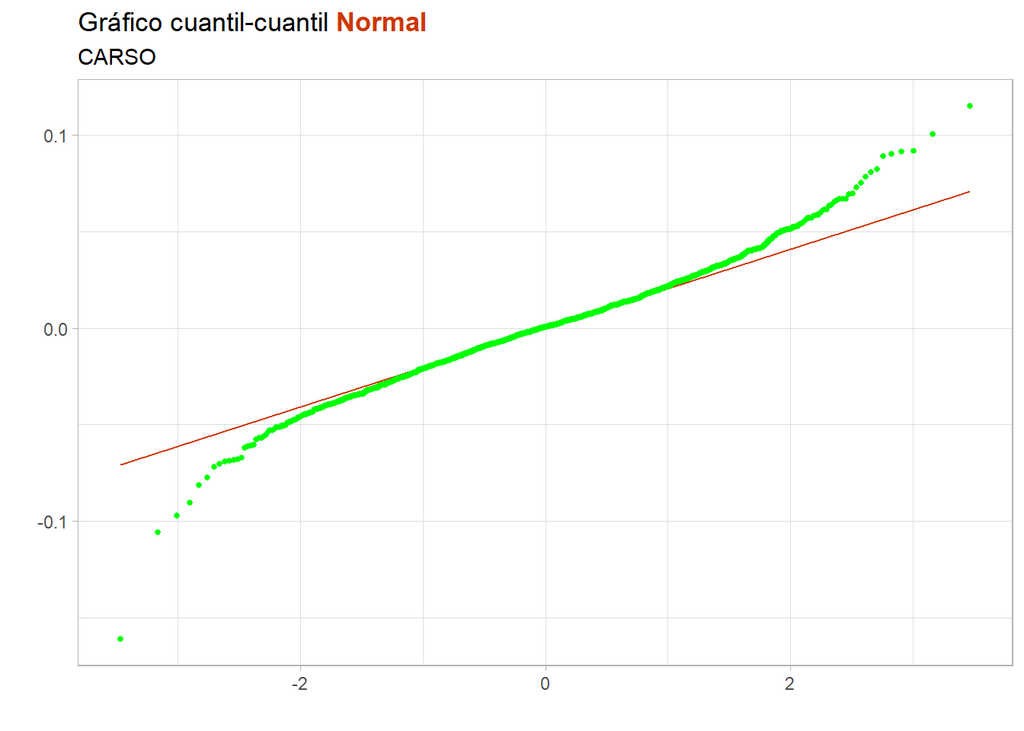

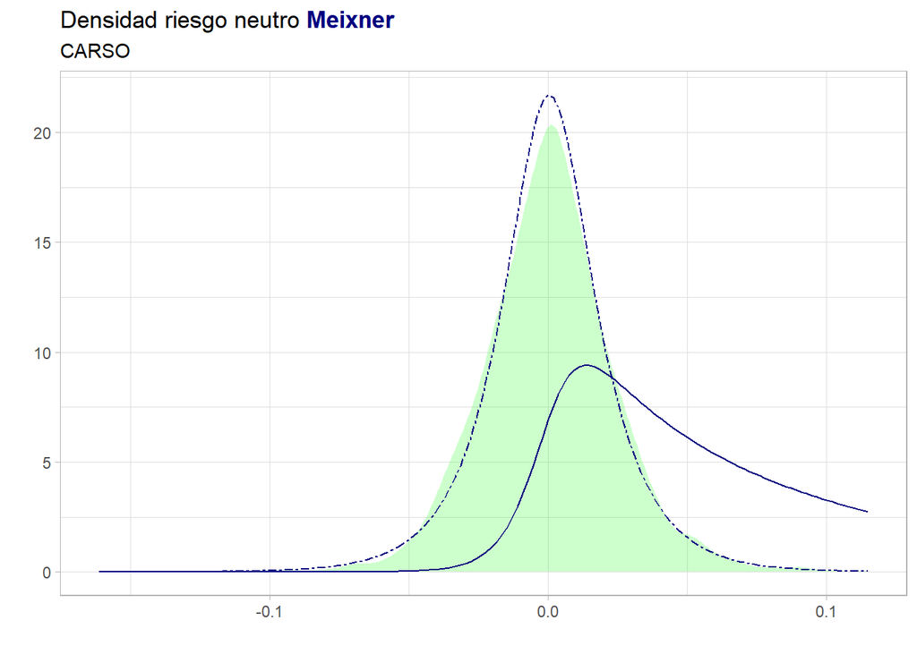

```r
color_gaussiano <- "orangered3"
# Nombre del modelo Meixner
nombre_modelo <- "Meixner"
# Color del modelo Meixner
color_modelo <- "navyblue"
dibuja_distribuciones("CARSO", desc_carso, rendimientos_carso, densidad_meixner_carso)
```

[figure not shown]

```r
dibuja_densidad_rn_normal("CARSO", rendimientos_carso, par_meixner_carso, par_rn_meixner_carso)
```

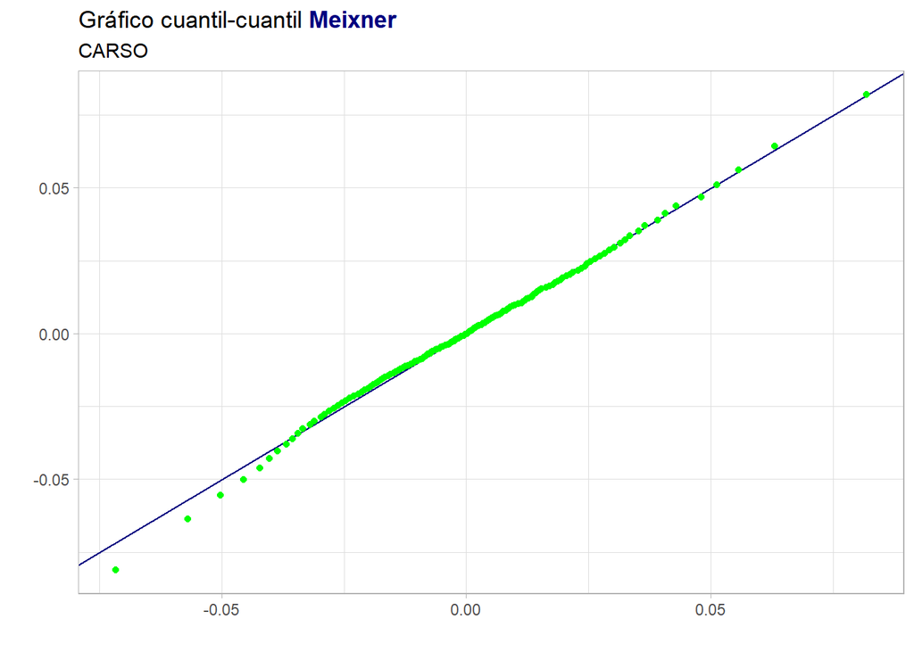

```r
dibuja_cuantiles_meixner("CARSO", cuantiles_meixner_carso)
```

# 8. Función Exportar Datos Phyton

**Parámetros:**

- Un vector con params riesgo neutro de las distr. Meixner y Normal, la tasa libre de riesgo y el último precio del histórico

**Valor de retorno:** - Un archivo para leer desde Python

```r
funcion_inputs_python <- function(df_S0, r, vector_params_rn, vector_params_rn_normal){
  names(r) <- "tasa_libre"
  df_vector_params_rn <- c(r, vector_params_rn,
                           vector_params_rn_normal) |> t() |> as.data.frame()
  objeto_a_python <- cbind(df_S0, df_vector_params_rn)
  return(objeto_a_python)
}
```

```r
data_inbursa <- funcion_inputs_python(S0_inbursa, r, par_rn_meixner_inbursa, par_rn_nomal_inbursa)
data_carso <- funcion_inputs_python(S0_carso, r, par_rn_meixner_carso, par_rn_normal_carso)

write.csv(data_inbursa, "C:/Users/erick/OneDrive/Documentos/Tesis/meixner/meixner_functions/data/data_inbursa.csv")
write.csv(data_carso, "C:/Users/erick/OneDrive/Documentos/Tesis/meixner/meixner_functions/data/data_carso.csv")
```